# Risk Factor Analysis

## Outcome Variable

**Outcome Variable:** ever_co

## Predictor Variables

**Intervention Variable:** birthwt

**Adjustment Set:**

- arm
- sex
- W_mage
- meducyrs
- feducyrs
- vagbrth
- single
- brthmon
- W_parity
- delta_W_mage
- delta_meducyrs
- delta_feducyrs
- delta_vagbrth
- delta_single
- delta_brthmon
- delta_W_parity

## Stratifying Variables

The analysis was stratified on these variable(s):

- agecat
- studyid
- country

## Data Summary

| agecat | studyid | country | birthwt | ever_co | n_cell | n |
| --- | --- | --- | --- | --- | --- | --- |
| 0-24 months | CMC-V-BCS-2002 | INDIA | Normal or high birthweight | 0 | 266 | 365 |
| 0-24 months | CMC-V-BCS-2002 | INDIA | Normal or high birthweight | 1 | 56 | 365 |
| 0-24 months | CMC-V-BCS-2002 | INDIA | Low birthweight | 0 | 16 | 365 |
| 0-24 months | CMC-V-BCS-2002 | INDIA | Low birthweight | 1 | 27 | 365 |
| 0-24 months | CMIN | BANGLADESH | Normal or high birthweight | 0 | 12 | 20 |
| 0-24 months | CMIN | BANGLADESH | Normal or high birthweight | 1 | 2 | 20 |
| 0-24 months | CMIN | BANGLADESH | Low birthweight | 0 | 4 | 20 |
| 0-24 months | CMIN | BANGLADESH | Low birthweight | 1 | 2 | 20 |
| 0-24 months | COHORTS | GUATEMALA | Normal or high birthweight | 0 | 763 | 929 |
| 0-24 months | COHORTS | GUATEMALA | Normal or high birthweight | 1 | 85 | 929 |
| 0-24 months | COHORTS | GUATEMALA | Low birthweight | 0 | 64 | 929 |
| 0-24 months | COHORTS | GUATEMALA | Low birthweight | 1 | 17 | 929 |
| 0-24 months | COHORTS | INDIA | Normal or high birthweight | 0 | 5088 | 6758 |
| 0-24 months | COHORTS | INDIA | Normal or high birthweight | 1 | 291 | 6758 |
| 0-24 months | COHORTS | INDIA | Low birthweight | 0 | 1059 | 6758 |
| 0-24 months | COHORTS | INDIA | Low birthweight | 1 | 320 | 6758 |
| 0-24 months | COHORTS | PHILIPPINES | Normal or high birthweight | 0 | 2283 | 3001 |
| 0-24 months | COHORTS | PHILIPPINES | Normal or high birthweight | 1 | 431 | 3001 |
| 0-24 months | COHORTS | PHILIPPINES | Low birthweight | 0 | 168 | 3001 |
| 0-24 months | COHORTS | PHILIPPINES | Low birthweight | 1 | 119 | 3001 |
| 0-24 months | CONTENT | PERU | Normal or high birthweight | 0 | 2 | 2 |
| 0-24 months | CONTENT | PERU | Normal or high birthweight | 1 | 0 | 2 |
| 0-24 months | CONTENT | PERU | Low birthweight | 0 | 0 | 2 |
| 0-24 months | CONTENT | PERU | Low birthweight | 1 | 0 | 2 |
| 0-24 months | EE | PAKISTAN | Normal or high birthweight | 0 | 154 | 378 |
| 0-24 months | EE | PAKISTAN | Normal or high birthweight | 1 | 91 | 378 |
| 0-24 months | EE | PAKISTAN | Low birthweight | 0 | 55 | 378 |
| 0-24 months | EE | PAKISTAN | Low birthweight | 1 | 78 | 378 |
| 0-24 months | GMS-Nepal | NEPAL | Normal or high birthweight | 0 | 374 | 685 |
| 0-24 months | GMS-Nepal | NEPAL | Normal or high birthweight | 1 | 103 | 685 |

[output cut: 294 more lines]

The following strata were considered:

- agecat: 0-24 months, studyid: CMC-V-BCS-2002, country: INDIA
- agecat: 0-24 months, studyid: CMIN, country: BANGLADESH
- agecat: 0-24 months, studyid: COHORTS, country: GUATEMALA
- agecat: 0-24 months, studyid: COHORTS, country: INDIA
- agecat: 0-24 months, studyid: COHORTS, country: PHILIPPINES
- agecat: 0-24 months, studyid: CONTENT, country: PERU
- agecat: 0-24 months, studyid: EE, country: PAKISTAN
- agecat: 0-24 months, studyid: GMS-Nepal, country: NEPAL
- agecat: 0-24 months, studyid: IRC, country: INDIA
- agecat: 0-24 months, studyid: JiVitA-3, country: BANGLADESH
- agecat: 0-24 months, studyid: JiVitA-4, country: BANGLADESH
- agecat: 0-24 months, studyid: Keneba, country: GAMBIA
- agecat: 0-24 months, studyid: MAL-ED, country: BANGLADESH
- agecat: 0-24 months, studyid: MAL-ED, country: BRAZIL
- agecat: 0-24 months, studyid: MAL-ED, country: INDIA
- agecat: 0-24 months, studyid: MAL-ED, country: NEPAL
- agecat: 0-24 months, studyid: MAL-ED, country: PERU
- agecat: 0-24 months, studyid: MAL-ED, country: SOUTH AFRICA
- agecat: 0-24 months, studyid: MAL-ED, country: TANZANIA, UNITED REPUBLIC OF
- agecat: 0-24 months, studyid: NIH-Birth, country: BANGLADESH
- agecat: 0-24 months, studyid: NIH-Crypto, country: BANGLADESH
- agecat: 0-24 months, studyid: PROBIT, country: BELARUS
- agecat: 0-24 months, studyid: PROVIDE, country: BANGLADESH
- agecat: 0-24 months, studyid: ResPak, country: PAKISTAN
- agecat: 0-24 months, studyid: SAS-CompFeed, country: INDIA
- agecat: 0-24 months, studyid: TanzaniaChild2, country: TANZANIA, UNITED REPUBLIC OF
- agecat: 0-24 months, studyid: ZVITAMBO, country: ZIMBABWE
- agecat: 0-6 months, studyid: CMC-V-BCS-2002, country: INDIA
- agecat: 0-6 months, studyid: CMIN, country: BANGLADESH
- agecat: 0-6 months, studyid: COHORTS, country: GUATEMALA
- agecat: 0-6 months, studyid: COHORTS, country: INDIA
- agecat: 0-6 months, studyid: COHORTS, country: PHILIPPINES
- agecat: 0-6 months, studyid: CONTENT, country: PERU
- agecat: 0-6 months, studyid: EE, country: PAKISTAN
- agecat: 0-6 months, studyid: GMS-Nepal, country: NEPAL
- agecat: 0-6 months, studyid: IRC, country: INDIA
- agecat: 0-6 months, studyid: JiVitA-3, country: BANGLADESH
- agecat: 0-6 months, studyid: JiVitA-4, country: BANGLADESH
- agecat: 0-6 months, studyid: Keneba, country: GAMBIA
- agecat: 0-6 months, studyid: MAL-ED, country: BANGLADESH
- agecat: 0-6 months, studyid: MAL-ED, country: BRAZIL
- agecat: 0-6 months, studyid: MAL-ED, country: INDIA
- agecat: 0-6 months, studyid: MAL-ED, country: NEPAL
- agecat: 0-6 months, studyid: MAL-ED, country: PERU
- agecat: 0-6 months, studyid: MAL-ED, country: SOUTH AFRICA
- agecat: 0-6 months, studyid: MAL-ED, country: TANZANIA, UNITED REPUBLIC OF
- agecat: 0-6 months, studyid: NIH-Birth, country: BANGLADESH
- agecat: 0-6 months, studyid: NIH-Crypto, country: BANGLADESH
- agecat: 0-6 months, studyid: PROBIT, country: BELARUS
- agecat: 0-6 months, studyid: PROVIDE, country: BANGLADESH
- agecat: 0-6 months, studyid: ResPak, country: PAKISTAN
- agecat: 0-6 months, studyid: SAS-CompFeed, country: INDIA
- agecat: 0-6 months, studyid: TanzaniaChild2, country: TANZANIA, UNITED REPUBLIC OF
- agecat: 0-6 months, studyid: ZVITAMBO, country: ZIMBABWE
- agecat: 6-24 months, studyid: CMC-V-BCS-2002, country: INDIA
- agecat: 6-24 months, studyid: CMIN, country: BANGLADESH
- agecat: 6-24 months, studyid: COHORTS, country: GUATEMALA
- agecat: 6-24 months, studyid: COHORTS, country: INDIA
- agecat: 6-24 months, studyid: COHORTS, country: PHILIPPINES
- agecat: 6-24 months, studyid: CONTENT, country: PERU
- agecat: 6-24 months, studyid: EE, country: PAKISTAN
- agecat: 6-24 months, studyid: GMS-Nepal, country: NEPAL
- agecat: 6-24 months, studyid: IRC, country: INDIA
- agecat: 6-24 months, studyid: JiVitA-3, country: BANGLADESH
- agecat: 6-24 months, studyid: JiVitA-4, country: BANGLADESH
- agecat: 6-24 months, studyid: Keneba, country: GAMBIA
- agecat: 6-24 months, studyid: MAL-ED, country: BANGLADESH
- agecat: 6-24 months, studyid: MAL-ED, country: BRAZIL
- agecat: 6-24 months, studyid: MAL-ED, country: INDIA
- agecat: 6-24 months, studyid: MAL-ED, country: NEPAL
- agecat: 6-24 months, studyid: MAL-ED, country: PERU
- agecat: 6-24 months, studyid: MAL-ED, country: SOUTH AFRICA
- agecat: 6-24 months, studyid: MAL-ED, country: TANZANIA, UNITED REPUBLIC OF
- agecat: 6-24 months, studyid: NIH-Birth, country: BANGLADESH
- agecat: 6-24 months, studyid: NIH-Crypto, country: BANGLADESH
- agecat: 6-24 months, studyid: PROBIT, country: BELARUS
- agecat: 6-24 months, studyid: PROVIDE, country: BANGLADESH
- agecat: 6-24 months, studyid: ResPak, country: PAKISTAN
- agecat: 6-24 months, studyid: SAS-CompFeed, country: INDIA
- agecat: 6-24 months, studyid: TanzaniaChild2, country: TANZANIA, UNITED REPUBLIC OF
- agecat: 6-24 months, studyid: ZVITAMBO, country: ZIMBABWE

### Dropped Strata

Some strata were dropped due to rare outcomes:

- agecat: 0-24 months, studyid: CMIN, country: BANGLADESH
- agecat: 0-24 months, studyid: CONTENT, country: PERU
- agecat: 0-24 months, studyid: MAL-ED, country: BRAZIL
- agecat: 0-24 months, studyid: MAL-ED, country: TANZANIA, UNITED REPUBLIC OF
- agecat: 0-24 months, studyid: PROBIT, country: BELARUS
- agecat: 0-24 months, studyid: ResPak, country: PAKISTAN
- agecat: 0-6 months, studyid: CMIN, country: BANGLADESH
- agecat: 0-6 months, studyid: COHORTS, country: GUATEMALA
- agecat: 0-6 months, studyid: CONTENT, country: PERU
- agecat: 0-6 months, studyid: MAL-ED, country: BANGLADESH
- agecat: 0-6 months, studyid: MAL-ED, country: BRAZIL
- agecat: 0-6 months, studyid: MAL-ED, country: NEPAL
- agecat: 0-6 months, studyid: MAL-ED, country: PERU
- agecat: 0-6 months, studyid: MAL-ED, country: SOUTH AFRICA
- agecat: 0-6 months, studyid: MAL-ED, country: TANZANIA, UNITED REPUBLIC OF
- agecat: 0-6 months, studyid: NIH-Crypto, country: BANGLADESH
- agecat: 0-6 months, studyid: PROBIT, country: BELARUS
- agecat: 0-6 months, studyid: ResPak, country: PAKISTAN
- agecat: 6-24 months, studyid: CMIN, country: BANGLADESH
- agecat: 6-24 months, studyid: CONTENT, country: PERU
- agecat: 6-24 months, studyid: MAL-ED, country: BRAZIL
- agecat: 6-24 months, studyid: MAL-ED, country: NEPAL
- agecat: 6-24 months, studyid: MAL-ED, country: PERU
- agecat: 6-24 months, studyid: MAL-ED, country: SOUTH AFRICA
- agecat: 6-24 months, studyid: MAL-ED, country: TANZANIA, UNITED REPUBLIC OF
- agecat: 6-24 months, studyid: PROBIT, country: BELARUS
- agecat: 6-24 months, studyid: ResPak, country: PAKISTAN

## Methods Detail

We’re interested in the causal parameters $E[Y_a]$ for all values of $a \in \mathcal{A}$. These parameters represent the mean outcome if, possibly contrary to fact, we intervened to set all units to have $A=a$. Under the randomization and positivity assumptions, these are identified by the statistical parameters $\psi_a=E_W[E_{Y|A,W}(Y|A=a,W)]$. In addition, we’re interested in the mean of $Y$, $E[Y]$ under no intervention (the observed mean). We will estimate these parameters by using SuperLearner to fit the relevant likelihood factors – $E_{Y|A,W}(Y|A=a,W)$ and $p(A=a|W)$, and then updating our likelihood fit using a joint TMLE.

For unadjusted analyses ($W=\{\}$), initial likelihoods were estimated using Lrnr_glm to estimate the simple $E(Y|A)$ and Lrnr_mean to estimate $p(A)$. For adjusted analyses, a small library containing Lrnr_glmnet, Lrnr_xgboost, and Lrnr_mean was used.

Having estimated these parameters, we will then use the delta method to estimate relative risks and attributable risks relative to a prespecified baseline level of $A$.

# Results Detail

## Results Plots

[figure not shown]

[figure not shown]

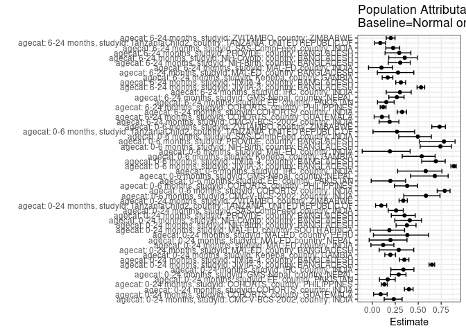

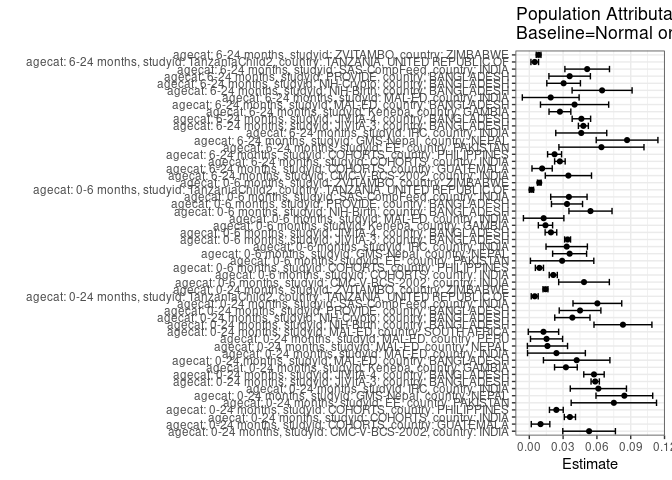

## Results Table

### Parameter: TSM

| agecat | studyid | country | intervention_level | baseline_level | estimate | ci_lower | ci_upper |
| --- | --- | --- | --- | --- | --- | --- | --- |
| 0-24 months | CMC-V-BCS-2002 | INDIA | Normal or high birthweight | NA | 0.1743247 | 0.1327735 | 0.2158759 |
| 0-24 months | CMC-V-BCS-2002 | INDIA | Low birthweight | NA | 0.6081403 | 0.4536328 | 0.7626479 |
| 0-24 months | COHORTS | GUATEMALA | Normal or high birthweight | NA | 0.0998071 | 0.0796289 | 0.1199854 |
| 0-24 months | COHORTS | GUATEMALA | Low birthweight | NA | 0.2068066 | 0.1183239 | 0.2952894 |
| 0-24 months | COHORTS | INDIA | Normal or high birthweight | NA | 0.0543757 | 0.0483165 | 0.0604350 |
| 0-24 months | COHORTS | INDIA | Low birthweight | NA | 0.2270538 | 0.2047750 | 0.2493326 |
| 0-24 months | COHORTS | PHILIPPINES | Normal or high birthweight | NA | 0.1592711 | 0.1455262 | 0.1730160 |
| 0-24 months | COHORTS | PHILIPPINES | Low birthweight | NA | 0.4128337 | 0.3563620 | 0.4693054 |
| 0-24 months | EE | PAKISTAN | Normal or high birthweight | NA | 0.3720562 | 0.3111640 | 0.4329484 |
| 0-24 months | EE | PAKISTAN | Low birthweight | NA | 0.5840031 | 0.4998574 | 0.6681488 |
| 0-24 months | GMS-Nepal | NEPAL | Normal or high birthweight | NA | 0.2090772 | 0.1723827 | 0.2457717 |
| 0-24 months | GMS-Nepal | NEPAL | Low birthweight | NA | 0.4924349 | 0.4243837 | 0.5604861 |
| 0-24 months | IRC | INDIA | Normal or high birthweight | NA | 0.1194012 | 0.0844787 | 0.1543236 |
| 0-24 months | IRC | INDIA | Low birthweight | NA | 0.4679964 | 0.3458811 | 0.5901117 |
| 0-24 months | JiVitA-3 | BANGLADESH | Normal or high birthweight | NA | 0.0315537 | 0.0283151 | 0.0347923 |
| 0-24 months | JiVitA-3 | BANGLADESH | Low birthweight | NA | 0.1724114 | 0.1643012 | 0.1805215 |
| 0-24 months | JiVitA-4 | BANGLADESH | Normal or high birthweight | NA | 0.1071956 | 0.0946321 | 0.1197591 |
| 0-24 months | JiVitA-4 | BANGLADESH | Low birthweight | NA | 0.3291754 | 0.2981143 | 0.3602365 |
| 0-24 months | Keneba | GAMBIA | Normal or high birthweight | NA | 0.1326682 | 0.1143246 | 0.1510117 |
| 0-24 months | Keneba | GAMBIA | Low birthweight | NA | 0.3483974 | 0.2865621 | 0.4102326 |
| 0-24 months | MAL-ED | BANGLADESH | Normal or high birthweight | NA | 0.1041108 | 0.0624035 | 0.1458181 |
| 0-24 months | MAL-ED | BANGLADESH | Low birthweight | NA | 0.2838011 | 0.1657629 | 0.4018393 |
| 0-24 months | MAL-ED | INDIA | Normal or high birthweight | NA | 0.1792269 | 0.1264502 | 0.2320037 |
| 0-24 months | MAL-ED | INDIA | Low birthweight | NA | 0.3071603 | 0.1498112 | 0.4645094 |
| 0-24 months | MAL-ED | NEPAL | Normal or high birthweight | NA | 0.0654206 | 0.0322204 | 0.0986207 |
| 0-24 months | MAL-ED | NEPAL | Low birthweight | NA | 0.2631579 | 0.0647309 | 0.4615849 |
| 0-24 months | MAL-ED | PERU | Normal or high birthweight | NA | 0.0248227 | 0.0066333 | 0.0430120 |
| 0-24 months | MAL-ED | PERU | Low birthweight | NA | 0.2941176 | 0.0771586 | 0.5110767 |
| 0-24 months | MAL-ED | SOUTH AFRICA | Normal or high birthweight | NA | 0.0551724 | 0.0288523 | 0.0814925 |
| 0-24 months | MAL-ED | SOUTH AFRICA | Low birthweight | NA | 0.2500000 | 0.0599205 | 0.4400795 |

[output cut: 78 more lines]

### Parameter: E(Y)

| agecat | studyid | country | intervention_level | baseline_level | estimate | ci_lower | ci_upper |
| --- | --- | --- | --- | --- | --- | --- | --- |
| 0-24 months | CMC-V-BCS-2002 | INDIA | NA | NA | 0.2273973 | 0.1843378 | 0.2704567 |
| 0-24 months | COHORTS | GUATEMALA | NA | NA | 0.1097955 | 0.0896809 | 0.1299101 |
| 0-24 months | COHORTS | INDIA | NA | NA | 0.0904114 | 0.0835737 | 0.0972490 |
| 0-24 months | COHORTS | PHILIPPINES | NA | NA | 0.1832722 | 0.1694278 | 0.1971167 |
| 0-24 months | EE | PAKISTAN | NA | NA | 0.4470899 | 0.3969017 | 0.4972782 |
| 0-24 months | GMS-Nepal | NEPAL | NA | NA | 0.2934307 | 0.2593074 | 0.3275539 |
| 0-24 months | IRC | INDIA | NA | NA | 0.1806931 | 0.1431275 | 0.2182586 |
| 0-24 months | JiVitA-3 | BANGLADESH | NA | NA | 0.0900373 | 0.0858293 | 0.0942453 |
| 0-24 months | JiVitA-4 | BANGLADESH | NA | NA | 0.1645963 | 0.1519758 | 0.1772167 |
| 0-24 months | Keneba | GAMBIA | NA | NA | 0.1651495 | 0.1465863 | 0.1837128 |
| 0-24 months | MAL-ED | BANGLADESH | NA | NA | 0.1461538 | 0.1031316 | 0.1891761 |
| 0-24 months | MAL-ED | INDIA | NA | NA | 0.2033195 | 0.1524012 | 0.2542378 |
| 0-24 months | MAL-ED | NEPAL | NA | NA | 0.0815451 | 0.0463297 | 0.1167604 |
| 0-24 months | MAL-ED | PERU | NA | NA | 0.0401338 | 0.0178494 | 0.0624181 |
| 0-24 months | MAL-ED | SOUTH AFRICA | NA | NA | 0.0677419 | 0.0397221 | 0.0957618 |
| 0-24 months | NIH-Birth | BANGLADESH | NA | NA | 0.2205638 | 0.1874426 | 0.2536851 |
| 0-24 months | NIH-Crypto | BANGLADESH | NA | NA | 0.0936675 | 0.0729118 | 0.1144233 |
| 0-24 months | PROVIDE | BANGLADESH | NA | NA | 0.1285714 | 0.1037574 | 0.1533855 |
| 0-24 months | SAS-CompFeed | INDIA | NA | NA | 0.2328676 | 0.1923832 | 0.2733520 |
| 0-24 months | TanzaniaChild2 | TANZANIA, UNITED REPUBLIC OF | NA | NA | 0.0489245 | 0.0402400 | 0.0576090 |
| 0-24 months | ZVITAMBO | ZIMBABWE | NA | NA | 0.0424552 | 0.0391029 | 0.0458075 |
| 0-6 months | CMC-V-BCS-2002 | INDIA | NA | NA | 0.0831025 | 0.0545881 | 0.1116169 |
| 0-6 months | COHORTS | INDIA | NA | NA | 0.0269983 | 0.0230857 | 0.0309109 |
| 0-6 months | COHORTS | PHILIPPINES | NA | NA | 0.0236667 | 0.0182263 | 0.0291070 |
| 0-6 months | EE | PAKISTAN | NA | NA | 0.1481481 | 0.1122884 | 0.1840079 |
| 0-6 months | GMS-Nepal | NEPAL | NA | NA | 0.0525547 | 0.0358322 | 0.0692773 |
| 0-6 months | IRC | INDIA | NA | NA | 0.0570720 | 0.0343950 | 0.0797490 |
| 0-6 months | JiVitA-3 | BANGLADESH | NA | NA | 0.0382613 | 0.0355749 | 0.0409477 |
| 0-6 months | JiVitA-4 | BANGLADESH | NA | NA | 0.0277653 | 0.0218336 | 0.0336971 |
| 0-6 months | Keneba | GAMBIA | NA | NA | 0.0266753 | 0.0186172 | 0.0347335 |
| 0-6 months | MAL-ED | INDIA | NA | NA | 0.0663900 | 0.0348925 | 0.0978876 |
| 0-6 months | NIH-Birth | BANGLADESH | NA | NA | 0.0732113 | 0.0523687 | 0.0940539 |
| 0-6 months | PROVIDE | BANGLADESH | NA | NA | 0.0428571 | 0.0278427 | 0.0578716 |
| 0-6 months | SAS-CompFeed | INDIA | NA | NA | 0.0709030 | 0.0481799 | 0.0936261 |
| 0-6 months | TanzaniaChild2 | TANZANIA, UNITED REPUBLIC OF | NA | NA | 0.0071700 | 0.0037732 | 0.0105668 |
| 0-6 months | ZVITAMBO | ZIMBABWE | NA | NA | 0.0120997 | 0.0102756 | 0.0139237 |
| 6-24 months | CMC-V-BCS-2002 | INDIA | NA | NA | 0.1835616 | 0.1437921 | 0.2233311 |
| 6-24 months | COHORTS | GUATEMALA | NA | NA | 0.1090909 | 0.0878048 | 0.1303770 |
| 6-24 months | COHORTS | INDIA | NA | NA | 0.0837039 | 0.0768626 | 0.0905453 |
| 6-24 months | COHORTS | PHILIPPINES | NA | NA | 0.1902351 | 0.1756031 | 0.2048671 |
| 6-24 months | EE | PAKISTAN | NA | NA | 0.4204852 | 0.3701867 | 0.4707837 |
| 6-24 months | GMS-Nepal | NEPAL | NA | NA | 0.3242784 | 0.2864427 | 0.3621142 |
| 6-24 months | IRC | INDIA | NA | NA | 0.1534653 | 0.1182750 | 0.1886557 |
| 6-24 months | JiVitA-3 | BANGLADESH | NA | NA | 0.0904706 | 0.0854589 | 0.0954824 |
| 6-24 months | JiVitA-4 | BANGLADESH | NA | NA | 0.1486997 | 0.1368826 | 0.1605168 |
| 6-24 months | Keneba | GAMBIA | NA | NA | 0.1622539 | 0.1434197 | 0.1810881 |
| 6-24 months | MAL-ED | BANGLADESH | NA | NA | 0.1434599 | 0.0987369 | 0.1881829 |
| 6-24 months | MAL-ED | INDIA | NA | NA | 0.1902655 | 0.1389784 | 0.2415526 |
| 6-24 months | NIH-Birth | BANGLADESH | NA | NA | 0.2126437 | 0.1775086 | 0.2477788 |
| 6-24 months | NIH-Crypto | BANGLADESH | NA | NA | 0.0863014 | 0.0659171 | 0.1066856 |
| 6-24 months | PROVIDE | BANGLADESH | NA | NA | 0.1221498 | 0.0962275 | 0.1480722 |
| 6-24 months | SAS-CompFeed | INDIA | NA | NA | 0.2269761 | 0.1910133 | 0.2629388 |
| 6-24 months | TanzaniaChild2 | TANZANIA, UNITED REPUBLIC OF | NA | NA | 0.0555834 | 0.0455321 | 0.0656347 |
| 6-24 months | ZVITAMBO | ZIMBABWE | NA | NA | 0.0411022 | 0.0373541 | 0.0448504 |

### Parameter: RR

| agecat | studyid | country | intervention_level | baseline_level | estimate | ci_lower | ci_upper |
| --- | --- | --- | --- | --- | --- | --- | --- |
| 0-24 months | CMC-V-BCS-2002 | INDIA | Normal or high birthweight | Normal or high birthweight | 1.000000 | 1.0000000 | 1.000000 |
| 0-24 months | CMC-V-BCS-2002 | INDIA | Low birthweight | Normal or high birthweight | 3.488549 | 2.4590407 | 4.949074 |
| 0-24 months | COHORTS | GUATEMALA | Normal or high birthweight | Normal or high birthweight | 1.000000 | 1.0000000 | 1.000000 |
| 0-24 months | COHORTS | GUATEMALA | Low birthweight | Normal or high birthweight | 2.072062 | 1.2903544 | 3.327336 |
| 0-24 months | COHORTS | INDIA | Normal or high birthweight | Normal or high birthweight | 1.000000 | 1.0000000 | 1.000000 |
| 0-24 months | COHORTS | INDIA | Low birthweight | Normal or high birthweight | 4.175645 | 3.6031026 | 4.839166 |
| 0-24 months | COHORTS | PHILIPPINES | Normal or high birthweight | Normal or high birthweight | 1.000000 | 1.0000000 | 1.000000 |
| 0-24 months | COHORTS | PHILIPPINES | Low birthweight | Normal or high birthweight | 2.592019 | 2.2069423 | 3.044285 |
| 0-24 months | EE | PAKISTAN | Normal or high birthweight | Normal or high birthweight | 1.000000 | 1.0000000 | 1.000000 |
| 0-24 months | EE | PAKISTAN | Low birthweight | Normal or high birthweight | 1.569664 | 1.2631084 | 1.950619 |
| 0-24 months | GMS-Nepal | NEPAL | Normal or high birthweight | Normal or high birthweight | 1.000000 | 1.0000000 | 1.000000 |
| 0-24 months | GMS-Nepal | NEPAL | Low birthweight | Normal or high birthweight | 2.355278 | 1.8863780 | 2.940733 |
| 0-24 months | IRC | INDIA | Normal or high birthweight | Normal or high birthweight | 1.000000 | 1.0000000 | 1.000000 |
| 0-24 months | IRC | INDIA | Low birthweight | Normal or high birthweight | 3.919529 | 2.6472155 | 5.803347 |
| 0-24 months | JiVitA-3 | BANGLADESH | Normal or high birthweight | Normal or high birthweight | 1.000000 | 1.0000000 | 1.000000 |
| 0-24 months | JiVitA-3 | BANGLADESH | Low birthweight | Normal or high birthweight | 5.464057 | 4.9010860 | 6.091694 |
| 0-24 months | JiVitA-4 | BANGLADESH | Normal or high birthweight | Normal or high birthweight | 1.000000 | 1.0000000 | 1.000000 |
| 0-24 months | JiVitA-4 | BANGLADESH | Low birthweight | Normal or high birthweight | 3.070792 | 2.6419514 | 3.569243 |
| 0-24 months | Keneba | GAMBIA | Normal or high birthweight | Normal or high birthweight | 1.000000 | 1.0000000 | 1.000000 |
| 0-24 months | Keneba | GAMBIA | Low birthweight | Normal or high birthweight | 2.626081 | 2.0980947 | 3.286936 |
| 0-24 months | MAL-ED | BANGLADESH | Normal or high birthweight | Normal or high birthweight | 1.000000 | 1.0000000 | 1.000000 |
| 0-24 months | MAL-ED | BANGLADESH | Low birthweight | Normal or high birthweight | 2.725953 | 1.5265596 | 4.867691 |
| 0-24 months | MAL-ED | INDIA | Normal or high birthweight | Normal or high birthweight | 1.000000 | 1.0000000 | 1.000000 |
| 0-24 months | MAL-ED | INDIA | Low birthweight | Normal or high birthweight | 1.713807 | 0.9494772 | 3.093422 |
| 0-24 months | MAL-ED | NEPAL | Normal or high birthweight | Normal or high birthweight | 1.000000 | 1.0000000 | 1.000000 |
| 0-24 months | MAL-ED | NEPAL | Low birthweight | Normal or high birthweight | 4.022556 | 1.6209628 | 9.982314 |
| 0-24 months | MAL-ED | PERU | Normal or high birthweight | Normal or high birthweight | 1.000000 | 1.0000000 | 1.000000 |
| 0-24 months | MAL-ED | PERU | Low birthweight | Normal or high birthweight | 11.848740 | 4.1890056 | 33.514548 |
| 0-24 months | MAL-ED | SOUTH AFRICA | Normal or high birthweight | Normal or high birthweight | 1.000000 | 1.0000000 | 1.000000 |
| 0-24 months | MAL-ED | SOUTH AFRICA | Low birthweight | Normal or high birthweight | 4.531250 | 1.8467195 | 11.118216 |

[output cut: 78 more lines]

### Parameter: PAR

| agecat | studyid | country | intervention_level | baseline_level | estimate | ci_lower | ci_upper |
| --- | --- | --- | --- | --- | --- | --- | --- |
| 0-24 months | CMC-V-BCS-2002 | INDIA | Normal or high birthweight | NA | 0.0530726 | 0.0297236 | 0.0764215 |
| 0-24 months | COHORTS | GUATEMALA | Normal or high birthweight | NA | 0.0099883 | 0.0017542 | 0.0182224 |
| 0-24 months | COHORTS | INDIA | Normal or high birthweight | NA | 0.0360356 | 0.0310636 | 0.0410076 |
| 0-24 months | COHORTS | PHILIPPINES | Normal or high birthweight | NA | 0.0240011 | 0.0178875 | 0.0301148 |
| 0-24 months | EE | PAKISTAN | Normal or high birthweight | NA | 0.0750337 | 0.0371601 | 0.1129073 |
| 0-24 months | GMS-Nepal | NEPAL | Normal or high birthweight | NA | 0.0843535 | 0.0591771 | 0.1095298 |
| 0-24 months | IRC | INDIA | Normal or high birthweight | NA | 0.0612919 | 0.0363631 | 0.0862207 |
| 0-24 months | JiVitA-3 | BANGLADESH | Normal or high birthweight | NA | 0.0584836 | 0.0547995 | 0.0621677 |
| 0-24 months | JiVitA-4 | BANGLADESH | Normal or high birthweight | NA | 0.0574007 | 0.0483380 | 0.0664633 |
| 0-24 months | Keneba | GAMBIA | Normal or high birthweight | NA | 0.0324814 | 0.0224089 | 0.0425539 |
| 0-24 months | MAL-ED | BANGLADESH | Normal or high birthweight | NA | 0.0420431 | 0.0125441 | 0.0715421 |
| 0-24 months | MAL-ED | INDIA | Normal or high birthweight | NA | 0.0240926 | -0.0015680 | 0.0497532 |
| 0-24 months | MAL-ED | NEPAL | Normal or high birthweight | NA | 0.0161245 | -0.0016978 | 0.0339468 |
| 0-24 months | MAL-ED | PERU | Normal or high birthweight | NA | 0.0153111 | 0.0010506 | 0.0295716 |
| 0-24 months | MAL-ED | SOUTH AFRICA | Normal or high birthweight | NA | 0.0125695 | -0.0009119 | 0.0260510 |
| 0-24 months | NIH-Birth | BANGLADESH | Normal or high birthweight | NA | 0.0831054 | 0.0574005 | 0.1088104 |
| 0-24 months | NIH-Crypto | BANGLADESH | Normal or high birthweight | NA | 0.0382250 | 0.0225919 | 0.0538580 |
| 0-24 months | PROVIDE | BANGLADESH | Normal or high birthweight | NA | 0.0450438 | 0.0265598 | 0.0635279 |
| 0-24 months | SAS-CompFeed | INDIA | Normal or high birthweight | NA | 0.0604032 | 0.0387774 | 0.0820291 |
| 0-24 months | TanzaniaChild2 | TANZANIA, UNITED REPUBLIC OF | Normal or high birthweight | NA | 0.0048073 | 0.0017230 | 0.0078915 |
| 0-24 months | ZVITAMBO | ZIMBABWE | Normal or high birthweight | NA | 0.0143469 | 0.0121502 | 0.0165436 |
| 0-6 months | CMC-V-BCS-2002 | INDIA | Normal or high birthweight | NA | 0.0485481 | 0.0260618 | 0.0710344 |
| 0-6 months | COHORTS | INDIA | Normal or high birthweight | NA | 0.0212654 | 0.0176809 | 0.0248500 |
| 0-6 months | COHORTS | PHILIPPINES | Normal or high birthweight | NA | 0.0089825 | 0.0053810 | 0.0125840 |
| 0-6 months | EE | PAKISTAN | Normal or high birthweight | NA | 0.0291220 | 0.0010002 | 0.0572437 |
| 0-6 months | GMS-Nepal | NEPAL | Normal or high birthweight | NA | 0.0357833 | 0.0207029 | 0.0508636 |
| 0-6 months | IRC | INDIA | Normal or high birthweight | NA | 0.0331914 | 0.0148417 | 0.0515411 |
| 0-6 months | JiVitA-3 | BANGLADESH | Normal or high birthweight | NA | 0.0339842 | 0.0313615 | 0.0366070 |
| 0-6 months | JiVitA-4 | BANGLADESH | Normal or high birthweight | NA | 0.0191971 | 0.0140390 | 0.0243552 |
| 0-6 months | Keneba | GAMBIA | Normal or high birthweight | NA | 0.0143592 | 0.0080332 | 0.0206851 |
| 0-6 months | MAL-ED | INDIA | Normal or high birthweight | NA | 0.0127315 | -0.0052142 | 0.0306772 |
| 0-6 months | NIH-Birth | BANGLADESH | Normal or high birthweight | NA | 0.0542988 | 0.0351779 | 0.0734197 |
| 0-6 months | PROVIDE | BANGLADESH | Normal or high birthweight | NA | 0.0334586 | 0.0196592 | 0.0472581 |
| 0-6 months | SAS-CompFeed | INDIA | Normal or high birthweight | NA | 0.0351306 | 0.0189965 | 0.0512647 |
| 0-6 months | TanzaniaChild2 | TANZANIA, UNITED REPUBLIC OF | Normal or high birthweight | NA | 0.0019275 | 0.0000868 | 0.0037682 |
| 0-6 months | ZVITAMBO | ZIMBABWE | Normal or high birthweight | NA | 0.0088584 | 0.0072583 | 0.0104584 |
| 6-24 months | CMC-V-BCS-2002 | INDIA | Normal or high birthweight | NA | 0.0346928 | 0.0141836 | 0.0552020 |
| 6-24 months | COHORTS | GUATEMALA | Normal or high birthweight | NA | 0.0113750 | 0.0023874 | 0.0203626 |
| 6-24 months | COHORTS | INDIA | Normal or high birthweight | NA | 0.0271506 | 0.0224646 | 0.0318367 |
| 6-24 months | COHORTS | PHILIPPINES | Normal or high birthweight | NA | 0.0224364 | 0.0162332 | 0.0286396 |
| 6-24 months | EE | PAKISTAN | Normal or high birthweight | NA | 0.0640178 | 0.0262675 | 0.1017681 |
| 6-24 months | GMS-Nepal | NEPAL | Normal or high birthweight | NA | 0.0867635 | 0.0593905 | 0.1141365 |
| 6-24 months | IRC | INDIA | Normal or high birthweight | NA | 0.0461051 | 0.0234803 | 0.0687298 |
| 6-24 months | JiVitA-3 | BANGLADESH | Normal or high birthweight | NA | 0.0479879 | 0.0435713 | 0.0524044 |
| 6-24 months | JiVitA-4 | BANGLADESH | Normal or high birthweight | NA | 0.0462256 | 0.0380327 | 0.0544185 |
| 6-24 months | Keneba | GAMBIA | Normal or high birthweight | NA | 0.0271821 | 0.0175095 | 0.0368547 |
| 6-24 months | MAL-ED | BANGLADESH | Normal or high birthweight | NA | 0.0401798 | 0.0099189 | 0.0704407 |
| 6-24 months | MAL-ED | INDIA | Normal or high birthweight | NA | 0.0189999 | -0.0061977 | 0.0441976 |
| 6-24 months | NIH-Birth | BANGLADESH | Normal or high birthweight | NA | 0.0645965 | 0.0379761 | 0.0912169 |
| 6-24 months | NIH-Crypto | BANGLADESH | Normal or high birthweight | NA | 0.0304553 | 0.0155390 | 0.0453717 |
| 6-24 months | PROVIDE | BANGLADESH | Normal or high birthweight | NA | 0.0358149 | 0.0174070 | 0.0542229 |
| 6-24 months | SAS-CompFeed | INDIA | Normal or high birthweight | NA | 0.0513680 | 0.0315816 | 0.0711543 |
| 6-24 months | TanzaniaChild2 | TANZANIA, UNITED REPUBLIC OF | Normal or high birthweight | NA | 0.0048303 | 0.0014429 | 0.0082178 |
| 6-24 months | ZVITAMBO | ZIMBABWE | Normal or high birthweight | NA | 0.0082621 | 0.0061704 | 0.0103538 |

### Parameter: PAF

| agecat | studyid | country | intervention_level | baseline_level | estimate | ci_lower | ci_upper |
| --- | --- | --- | --- | --- | --- | --- | --- |
| 0-24 months | CMC-V-BCS-2002 | INDIA | Normal or high birthweight | NA | 0.2333914 | 0.1296920 | 0.3247346 |
| 0-24 months | COHORTS | GUATEMALA | Normal or high birthweight | NA | 0.0909722 | 0.0143640 | 0.1616260 |
| 0-24 months | COHORTS | INDIA | Normal or high birthweight | NA | 0.3985741 | 0.3493564 | 0.4440687 |
| 0-24 months | COHORTS | PHILIPPINES | Normal or high birthweight | NA | 0.1309589 | 0.0978760 | 0.1628286 |
| 0-24 months | EE | PAKISTAN | Normal or high birthweight | NA | 0.1678269 | 0.0776854 | 0.2491585 |
| 0-24 months | GMS-Nepal | NEPAL | Normal or high birthweight | NA | 0.2874732 | 0.1988928 | 0.3662591 |
| 0-24 months | IRC | INDIA | Normal or high birthweight | NA | 0.3392045 | 0.2019147 | 0.4528772 |
| 0-24 months | JiVitA-3 | BANGLADESH | Normal or high birthweight | NA | 0.6495482 | 0.6176879 | 0.6787534 |
| 0-24 months | JiVitA-4 | BANGLADESH | Normal or high birthweight | NA | 0.3487361 | 0.2949495 | 0.3984195 |
| 0-24 months | Keneba | GAMBIA | Normal or high birthweight | NA | 0.1966786 | 0.1360310 | 0.2530690 |
| 0-24 months | MAL-ED | BANGLADESH | Normal or high birthweight | NA | 0.2876631 | 0.0747974 | 0.4515539 |
| 0-24 months | MAL-ED | INDIA | Normal or high birthweight | NA | 0.1184961 | -0.0151037 | 0.2345125 |
| 0-24 months | MAL-ED | NEPAL | Normal or high birthweight | NA | 0.1977373 | -0.0342233 | 0.3776727 |
| 0-24 months | MAL-ED | PERU | Normal or high birthweight | NA | 0.3815012 | 0.0126056 | 0.6125755 |
| 0-24 months | MAL-ED | SOUTH AFRICA | Normal or high birthweight | NA | 0.1855501 | -0.0227823 | 0.3514469 |
| 0-24 months | NIH-Birth | BANGLADESH | Normal or high birthweight | NA | 0.3767863 | 0.2587319 | 0.4760394 |
| 0-24 months | NIH-Crypto | BANGLADESH | Normal or high birthweight | NA | 0.4080917 | 0.2452504 | 0.5357992 |
| 0-24 months | PROVIDE | BANGLADESH | Normal or high birthweight | NA | 0.3503410 | 0.2069496 | 0.4678058 |
| 0-24 months | SAS-CompFeed | INDIA | Normal or high birthweight | NA | 0.2593887 | 0.1727555 | 0.3369493 |
| 0-24 months | TanzaniaChild2 | TANZANIA, UNITED REPUBLIC OF | Normal or high birthweight | NA | 0.0982591 | 0.0353455 | 0.1570696 |
| 0-24 months | ZVITAMBO | ZIMBABWE | Normal or high birthweight | NA | 0.3379303 | 0.2915261 | 0.3812952 |
| 0-6 months | CMC-V-BCS-2002 | INDIA | Normal or high birthweight | NA | 0.5841951 | 0.3432077 | 0.7367604 |
| 0-6 months | COHORTS | INDIA | Normal or high birthweight | NA | 0.7876574 | 0.7063495 | 0.8464522 |
| 0-6 months | COHORTS | PHILIPPINES | Normal or high birthweight | NA | 0.3795424 | 0.2403576 | 0.4932252 |
| 0-6 months | EE | PAKISTAN | Normal or high birthweight | NA | 0.1965732 | -0.0119874 | 0.3621515 |
| 0-6 months | GMS-Nepal | NEPAL | Normal or high birthweight | NA | 0.6808758 | 0.4166183 | 0.8254312 |
| 0-6 months | IRC | INDIA | Normal or high birthweight | NA | 0.5815704 | 0.2758198 | 0.7582324 |
| 0-6 months | JiVitA-3 | BANGLADESH | Normal or high birthweight | NA | 0.8882136 | 0.8553385 | 0.9136176 |
| 0-6 months | JiVitA-4 | BANGLADESH | Normal or high birthweight | NA | 0.6914055 | 0.5378170 | 0.7939549 |
| 0-6 months | Keneba | GAMBIA | Normal or high birthweight | NA | 0.5382939 | 0.3255631 | 0.6839252 |
| 0-6 months | MAL-ED | INDIA | Normal or high birthweight | NA | 0.1917683 | -0.1099638 | 0.4114776 |
| 0-6 months | NIH-Birth | BANGLADESH | Normal or high birthweight | NA | 0.7416720 | 0.5209728 | 0.8606899 |
| 0-6 months | PROVIDE | BANGLADESH | Normal or high birthweight | NA | 0.7807018 | 0.5147381 | 0.9008953 |
| 0-6 months | SAS-CompFeed | INDIA | Normal or high birthweight | NA | 0.4954744 | 0.2876844 | 0.6426499 |
| 0-6 months | TanzaniaChild2 | TANZANIA, UNITED REPUBLIC OF | Normal or high birthweight | NA | 0.2688305 | 0.0076893 | 0.4612485 |
| 0-6 months | ZVITAMBO | ZIMBABWE | Normal or high birthweight | NA | 0.7321154 | 0.6476853 | 0.7963123 |
| 6-24 months | CMC-V-BCS-2002 | INDIA | Normal or high birthweight | NA | 0.1889982 | 0.0746224 | 0.2892372 |
| 6-24 months | COHORTS | GUATEMALA | Normal or high birthweight | NA | 0.1042708 | 0.0200958 | 0.1812150 |
| 6-24 months | COHORTS | INDIA | Normal or high birthweight | NA | 0.3243650 | 0.2720815 | 0.3728932 |
| 6-24 months | COHORTS | PHILIPPINES | Normal or high birthweight | NA | 0.1179406 | 0.0854748 | 0.1492538 |
| 6-24 months | EE | PAKISTAN | Normal or high birthweight | NA | 0.1522475 | 0.0569240 | 0.2379359 |
| 6-24 months | GMS-Nepal | NEPAL | Normal or high birthweight | NA | 0.2675586 | 0.1801836 | 0.3456213 |
| 6-24 months | IRC | INDIA | Normal or high birthweight | NA | 0.3004266 | 0.1515326 | 0.4231918 |
| 6-24 months | JiVitA-3 | BANGLADESH | Normal or high birthweight | NA | 0.5304247 | 0.4869901 | 0.5701819 |
| 6-24 months | JiVitA-4 | BANGLADESH | Normal or high birthweight | NA | 0.3108657 | 0.2554285 | 0.3621752 |
| 6-24 months | Keneba | GAMBIA | Normal or high birthweight | NA | 0.1675281 | 0.1076865 | 0.2233564 |
| 6-24 months | MAL-ED | BANGLADESH | Normal or high birthweight | NA | 0.2800770 | 0.0547408 | 0.4516962 |
| 6-24 months | MAL-ED | INDIA | Normal or high birthweight | NA | 0.0998601 | -0.0410779 | 0.2217184 |
| 6-24 months | NIH-Birth | BANGLADESH | Normal or high birthweight | NA | 0.3037781 | 0.1741193 | 0.4130812 |
| 6-24 months | NIH-Crypto | BANGLADESH | Normal or high birthweight | NA | 0.3528948 | 0.1788263 | 0.4900651 |
| 6-24 months | PROVIDE | BANGLADESH | Normal or high birthweight | NA | 0.2932048 | 0.1391240 | 0.4197080 |
| 6-24 months | SAS-CompFeed | INDIA | Normal or high birthweight | NA | 0.2263144 | 0.1472357 | 0.2980599 |
| 6-24 months | TanzaniaChild2 | TANZANIA, UNITED REPUBLIC OF | Normal or high birthweight | NA | 0.0869023 | 0.0258441 | 0.1441335 |
| 6-24 months | ZVITAMBO | ZIMBABWE | Normal or high birthweight | NA | 0.2010128 | 0.1517575 | 0.2474080 |